# Visual Exploration of Data - Assignment 1

# Part 4 - Your Choice Visualization - Comparing total number of claims per month, 2014 and 2015

```python
df14 = pd.read_csv("assets/claims-2014.csv")
df15 = pd.read_csv("assets/claims-2015.csv")
```

```python
#Output head of df14 to view field names
df14.head(1)
```

|  | Claim Number | Date Received | Incident Date | Airport Code | Airport Name | Airline Name | Claim Type | Claim Site | Item Category | Close Amount | Disposition |
| --- | --- | --- | --- | --- | --- | --- | --- | --- | --- | --- | --- |
| 0 | 2.013080e+12 | 13-Jan-14 | 21-Dec-12 | HPN | Westchester County, White Plains | USAir | Personal Injury | Checked Baggage | Audio/Video; Jewelry & Watches | 0.00 | Deny |

```python
#Output head of df15 to view field names, and change field names to match df14 exactly to make concatenation easier
df15.rename(columns={"Incident D": "Incident Date"}, inplace = True)
df15.head(1)
```

|  | Claim Number | Date Received | Incident Date | Airport Code | Airport Name | Airline Name | Claim Type | Claim Site | Item Category | Close Amount | Disposition |
| --- | --- | --- | --- | --- | --- | --- | --- | --- | --- | --- | --- |
| 0 | 2015060222904 | 05/28/2015 | 05/21/2015 | ABE | Lehigh Valley International Airport, Allentown | Allegiant Air | Property Damage | Checkpoint | Personal Electronics | 0 | Deny |

```python
#remove all rows where close amount as no value
df14['Close Amount'] = df14['Close Amount'].str.replace("-","")
df14['Close Amount'].replace('', np.nan, inplace=True)
df14['Close Amount'] = df14['Close Amount'].astype('float64')
df14.dropna(subset=['Close Amount'], inplace=True)


df15['Close Amount'] = df15['Close Amount'].str.replace("-","")
df15['Close Amount'].replace('', np.nan, inplace=True)
df15['Close Amount'] = df15['Close Amount'].astype('float64')
df15.dropna(subset=['Close Amount'], inplace=True)
```

```python
#Convert Date Received column to datetime and then extract only year out of date. Get rid of years that don't == 2014 & 2015
#After deletion, extract the month from the full date to use for bar plot
#Create count of incidents to per month column using mapping dictionary for each dataframe
#As a final step, combine both dataframes using pd.concat
df14['Incident Date'] = df14['Incident Date'].astype('datetime64[ns]')
df14['Incident Date'] = df14['Incident Date'].astype('datetime64[ns]')
df14['Year Received'] = df14['Incident Date'].dt.year
df14 = df14[df14['Year Received'] == 2014]
df14['Month Received'] = df14['Incident Date'].dt.month
counts_1 = df14['Month Received'].value_counts().to_dict()
df14['Count of incidents']= df14['Month Received'].map(counts_1)



df15['Incident Date'] = df15['Incident Date'].astype('datetime64[ns]')
df15['Incident Date'] = df15['Incident Date'].astype('datetime64[ns]')
df15['Year Received'] = df15['Incident Date'].dt.year
df15 = df15[df15['Year Received'] == 2015]
df15['Month Received'] = df15['Incident Date'].dt.month
counts_2 = df15['Month Received'].value_counts().to_dict()
df15['Count of incidents']= df15['Month Received'].map(counts_2)



frames = [df14, df15]

df_concat = pd.concat(frames)
```

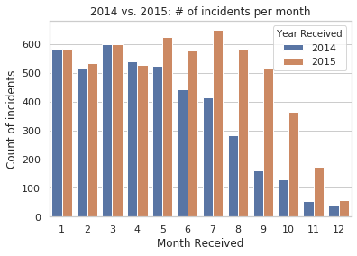

```python
#Now, plot a side by side bar chart comparing incidents per month for 2015 and 2015, using seaborn
fourteen_vs_fifteen = sns.barplot(x="Month Received", y="Count of incidents", hue="Year Received", data=df_concat).set_title('2014 vs. 2015: # of incidents per month')
```

# Justification

The double bar chart shown above displays the total number of incidents recorded per month(regardless of disposition) for 2014 and 2015, and plots them side-by-side. I believe that doing so facilitates much easier comparison than visually comparing two individual bar plots. Furthermore, since obtaining value counts was the main objective of this particlar analysis, a bar chart was a better designed medium to do so. Though a histogram is somewhat similar in function, since each group in this analysis is defined by a categorical variable(month) as opposed to a quantitative variable, it would not have been a feasible representation in this particular case.

At a glance, it is striking to see how many more incidents generally occured each month in 2015 compared to 2014. Only in April were the number of incidents higher in 2014 than 2015, albeit by a somewhat negligible amount. The months where the greatest number of incidents were observed are March and July, for 2014 and 2015 respectively, whereas the month where the least number of incidents was observed was December, for both 2014 and 2015.